# Statistical Analysis of Insurance Policies

Neha Deshmukh

8 August 2020

## About the data

The data talks about details of customers who purchased different Auto Insurance Policies from the Company. For our CLV analysis, I have analysed the information of 9134 customers. There are 23 different variables. They are a mix of Categorical and Continous variables. In order to predict the CLV, the dependent variable from the dataset is Customer Lifetime Value.

Independent Variables are: Customer, StateCustomerLifetimeValue, Response, Coverage, Education, EffectiveToDate, EmploymentStatus, Gender, Income, LocationCode, MaritalStatus, MonthlyPremiumAuto, MonthsSinceLastClaim, MonthsSincePolicyInception, NumberofOpenComplaints, NumberofPoliciesPolicyType, Policy, RenewOfferType, SalesChannel, TotalClaimAmountVehicleClass, VehicleSize

Continues Independed Variables are : CustomerLifetimeValue, Income,MonthlyPremiumAuto, MonthsSinceLastClaim, MonthsSincePolicyInception, NumberofOpenComplaints, NumberofPolicies, TotalClaimAmount

There are no null values, so no further action required to replace missing or null values. “Customer” column is serial number so it is insignificat for analysis and removed from the dataset.

The unique values for each variable are as follows:

```
##                         State       Customer_Lifetime_Value
##                             5                          8041
##                      Response                      Coverage
##                             2                             3
##                     Education             Effective_To_Date
##                             5                            59
##              EmploymentStatus                        Gender
##                             5                             2
##                        Income                 Location_Code
##                          5694                             3
##                Marital_Status          Monthly_Premium_Auto
##                             3                           202
##       Months_Since_Last_Claim Months_Since_Policy_Inception
##                            36                           100
##     Number_of_Open_Complaints            Number_of_Policies
##                             6                             9
##                   Policy_Type                        Policy
##                             3                             9
##              Renew_Offer_Type                 Sales_Channel
##                             4                             4
##            Total_Claim_Amount                 Vehicle_Class
##                          5106                             6
##                  Vehicle_Size
##                             3
```

## Objective of Analysis:

The objective of this analysis is to **Predict the Customer Lifetime Value of the Customers (CLV)**. Customer lifetime value is the metric that indicates the total revenue a business can reasonably expect from a single customer account. It represents the amount of money that a customer is expected is spend on a particular company’s product or services. This metric can help the Auto Insurance Company to decide on the amount of money to invest in retaining the existing customers and acquiring new customers.

CLV is calculated as:

- **Calculate average purchase value**: Calculate this number by dividing your company’s total revenue in a time period (usually one year) by the number of purchases over the course of that same time period.
- **Calculate average purchase frequency rate**: Calculate this number by dividing the number of purchases by the number of unique customers who made purchases during that time period.
- **Calculate customer value**: Calculate this number by multiplying the average purchase value by the average purchase frequency rate.
- **Calculate average customer lifespan**: Calculate this number by averaging the number of years a customer continues purchasing from your company.
- **Calculate CLTV**: multiply customer value by the average customer lifespan. This will give you the revenue you can reasonably expect an average customer to generate for your company over the course of their relationship with you.

## Exploratory Analysis to discover interesting patterns:

### Customer Lifetime Value:

```
##    Min. 1st Qu.  Median    Mean 3rd Qu.    Max.
##    1898    3994    5780    8005    8962   83325
```

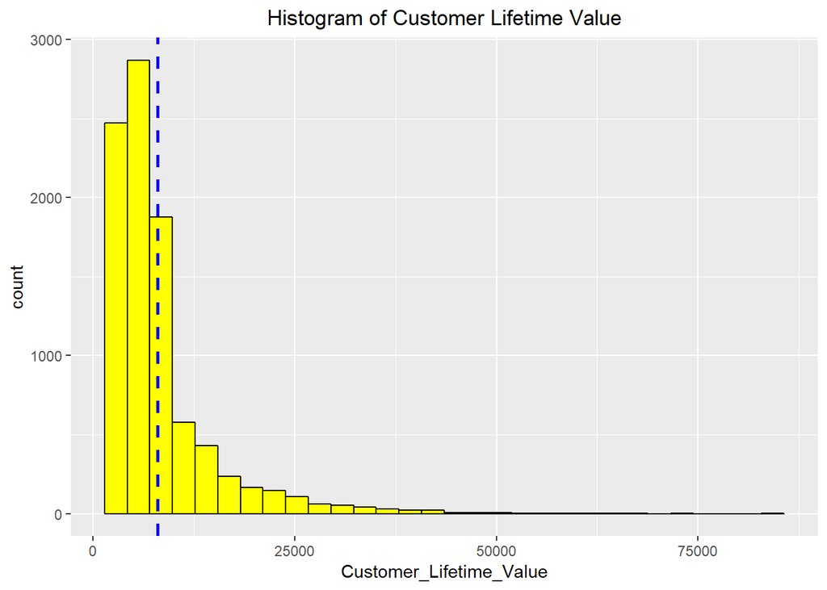

The histogram indicates a distribution that is heavily skewed with a very large tail. There are a lot of Customers with low CLV. Very few customers with high CLV.

### Monthly Premium Auto

```
##    Min. 1st Qu.  Median    Mean 3rd Qu.    Max.
##   61.00   68.00   83.00   93.22  109.00  298.00
```

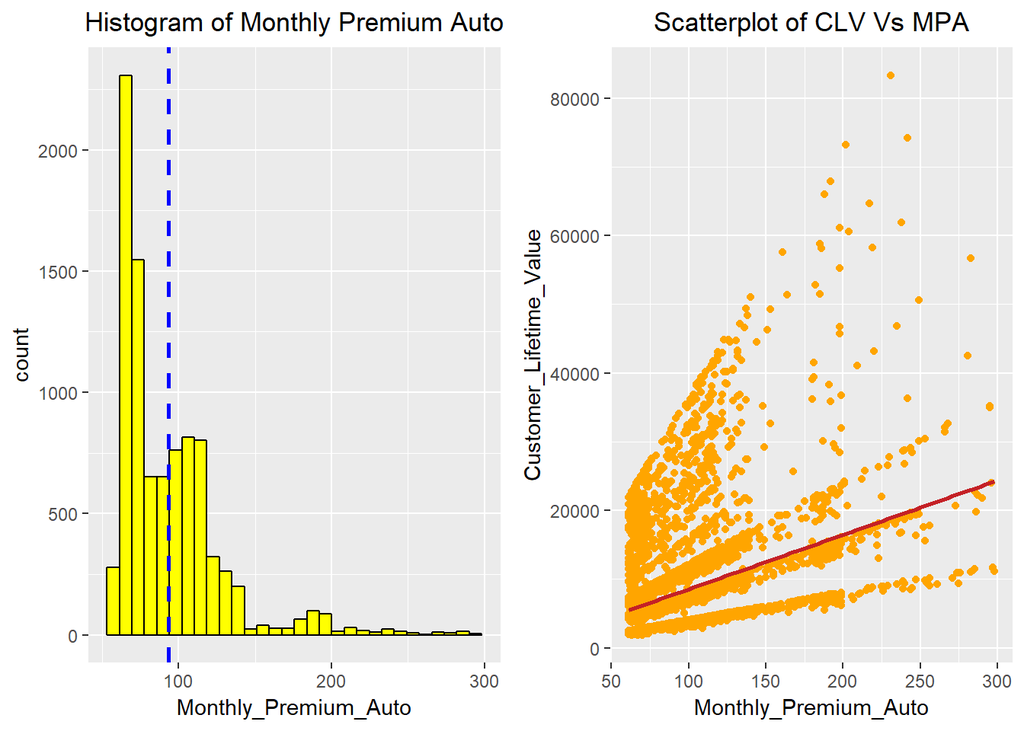

From the scatter plot, it is clearly visible that on MPA, CLV is also Increasing. Monthly premiums follow a trend similar to CLV although the distribution is NOT as skewed or as long tailed as CLV.

### Total Claim Amount

```
##     Min.  1st Qu.   Median     Mean  3rd Qu.     Max.
##    0.099  272.258  383.945  434.089  547.515 2893.240
```

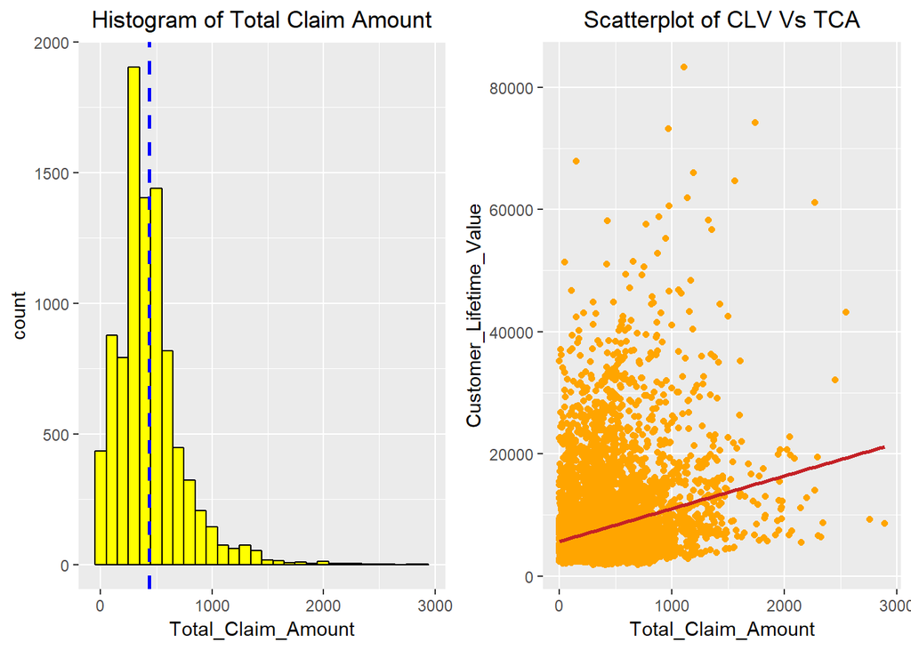

### Relationship between CLV and continous variables

[figure not shown]

[figure not shown]

[figure not shown]

Looking at the plots above, the following points can be concluded:

- Customer lifetime value is less when the total claim amount is less.
- There are more people with less customer lifetime value and the data is skewed.
- As the number of open complaints increase, the customer lifetime value is decreases.

### Correlations with Customer Values

#### Correlation of Income with CLV

```
## [1] 0.02436566
```

Since, the correlation value between CLV and Income is slightly greater than 0, as Income increases, so does the CLV of the customer. But these values are loosely correlated.

#### Correlation of Monthly Auto Premium with CLV

```
## [1] 0.3962617
```

Since, the correlation value between CLV and Monthly Auto Premium is greater than 0, as Monthly Auto Premium increases, so does the CLV of the customer.

#### Correlation of Months since last claim with CLV

```
## [1] 0.01151668
```

Since, the correlation value between CLV and Months since last claim is slightly greater than 0, as Months since last claim increases, so does the CLV of the customer. But these values are loosely correlated.

#### Correlation of Months since policy inception with CLV

```
## [1] 0.009418381
```

Since, the correlation value between CLV and Months since inception of the policy is slightly greater than 0, as Months since inception of the policy increases, so does the CLV of the customer. But these values are very loosely correlated.

#### Correlation of Total Claim Amount

```
## [1] 0.2264509
```

Since, the correlation value between CLV and Total Claim Amount of the policy is greater than 0, as Total Claim Amount increases, so does the CLV of the customer.

#### Correlation of Number of Open Complaints

```
## [1] -0.03634319
```

Since, the correlation value between CLV and Number of Complaints of the policy is slightly lesser than 0, the CLV increases as Number of Complaints decreases.

## Inferential Statistics

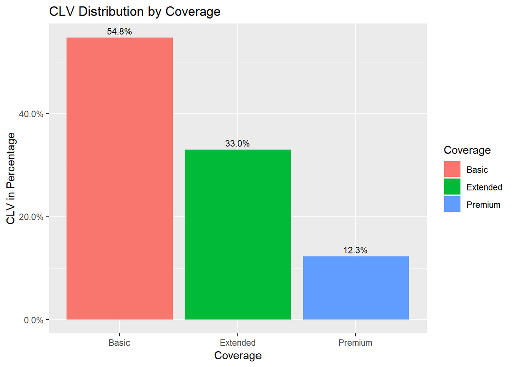

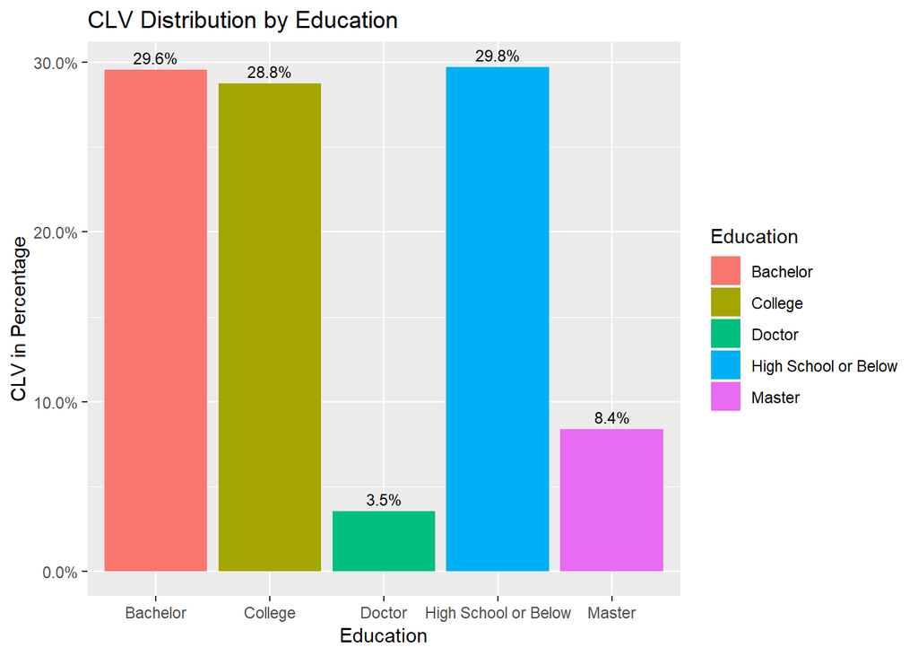

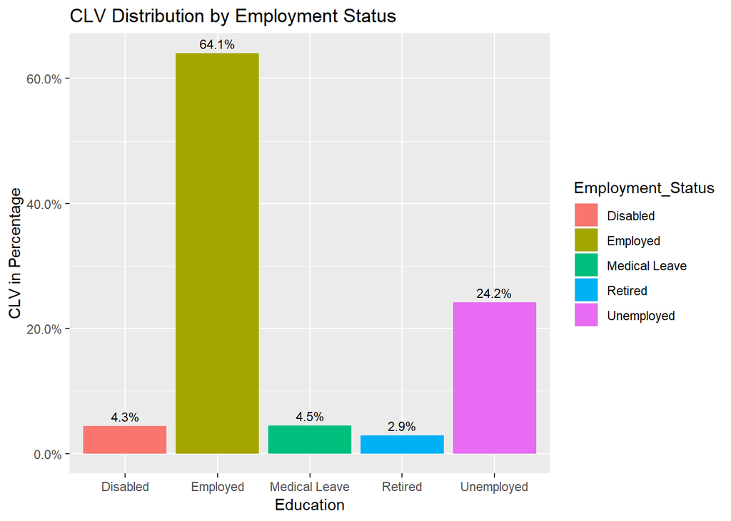

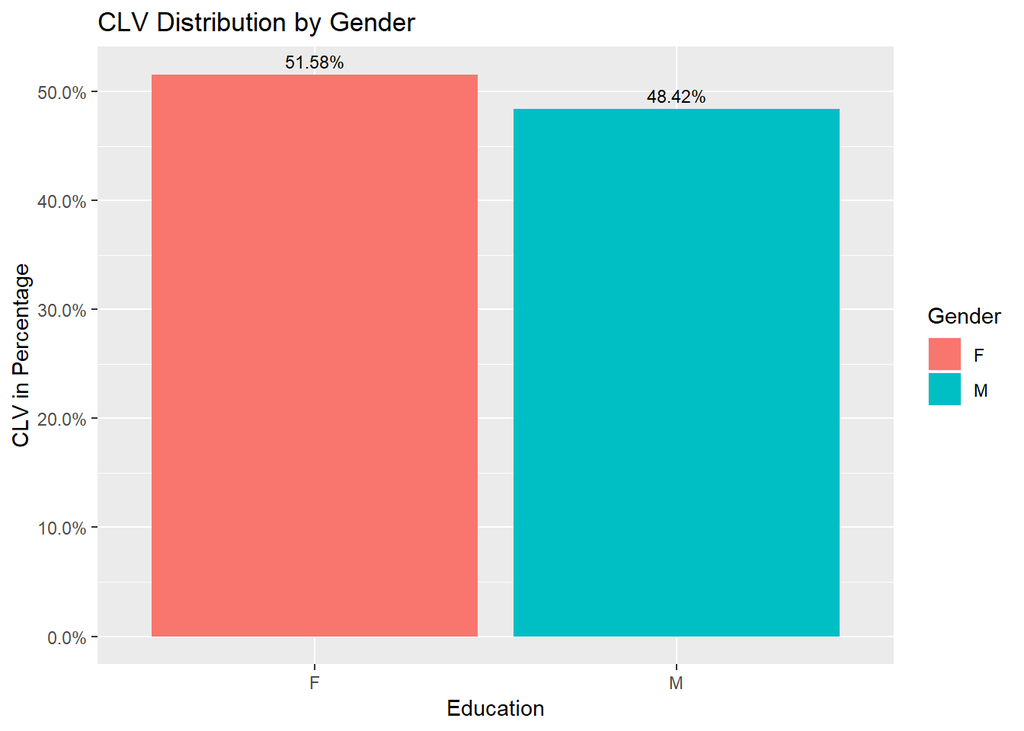

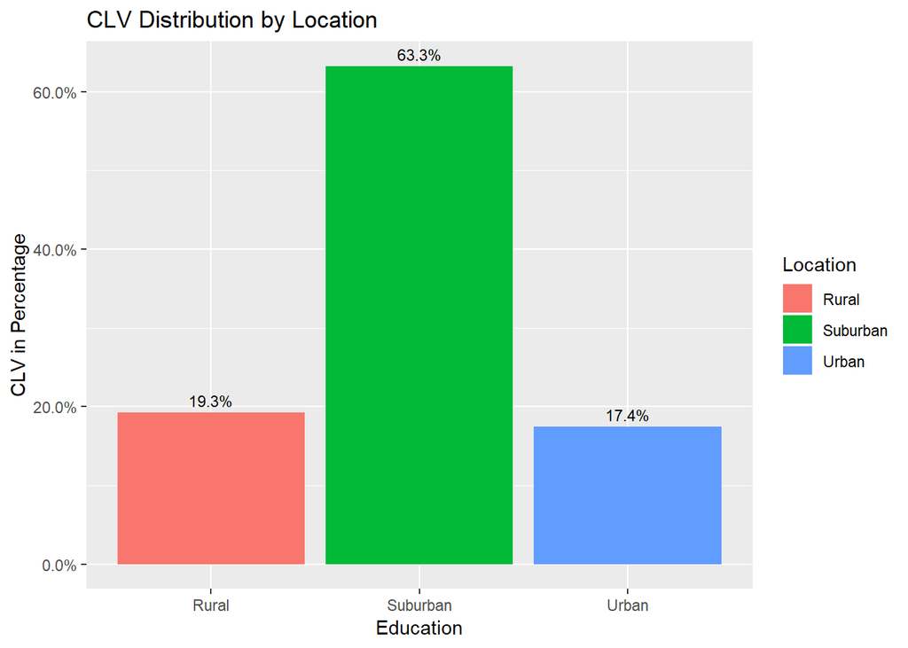

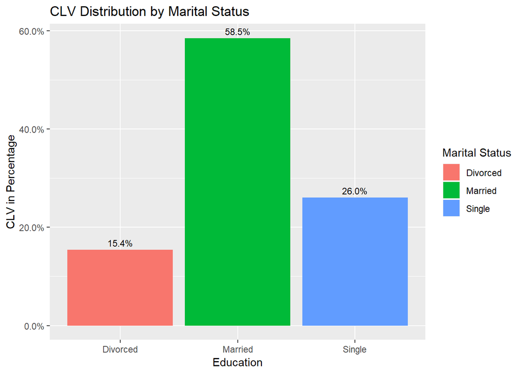

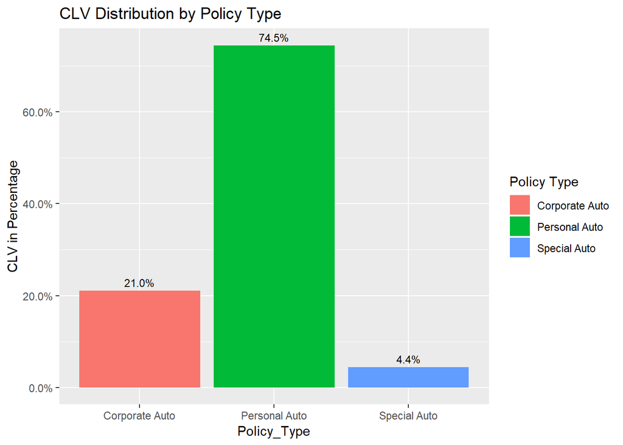

[figure not shown]